# ML

```python
import pandas as pd
import matplotlib
import matplotlib.pyplot as plt
import numpy as np
import time
from pandas.api.types import is_numeric_dtype
import seaborn as sns
from scipy.stats import norm
import seaborn as sb
from sklearn.preprocessing import StandardScaler
from sklearn.preprocessing import MinMaxScaler
from sklearn import preprocessing
from sklearn.preprocessing import LabelEncoder
from sklearn.preprocessing import OneHotEncoder
from sklearn.model_selection import train_test_split
from sklearn.metrics import mean_squared_error
from sklearn.metrics import mean_absolute_error
from sklearn.linear_model import LinearRegression
from sklearn.tree import DecisionTreeRegressor
from sklearn.neighbors import KNeighborsRegressor
from sklearn.model_selection import GridSearchCV
from sklearn.ensemble import RandomForestRegressor
from sklearn.ensemble import VotingRegressor
from sklearn.metrics import confusion_matrix
from sklearn.datasets import make_classification
from sklearn.metrics import accuracy_score,classification_report
from sklearn.metrics import confusion_matrix, ConfusionMatrixDisplay
from sklearn import metrics
import matplotlib.pyplot as plt
from sklearn.linear_model import LogisticRegression
from sklearn.svm import SVR
```

```python
DataFrame = pd.read_csv('diabetes.csv')
DataFrame
```

|  | Pregnancies | Glucose | BloodPressure | SkinThickness | Insulin | BMI | DiabetesPedigreeFunction | Age | Outcome |
| --- | --- | --- | --- | --- | --- | --- | --- | --- | --- |
| 0 | 6.0 | 148.0 | 72.0 | 35.0 | 0.0 | 33.6 | 0.627 | 50.0 | 1 |
| 1 | 1.0 | 85.0 | 66.0 | 29.0 | 0.0 | 26.6 | 0.351 | 31.0 | 0 |
| 2 | NaN | 183.0 | 64.0 | 0.0 | 0.0 | 23.3 | 0.672 | 32.0 | 1 |
| 3 | 1.0 | 89.0 | 66.0 | 23.0 | 94.0 | 28.1 | 0.167 | 21.0 | 0 |
| 4 | NaN | 137.0 | 40.0 | 35.0 | 168.0 | NaN | NaN | 33.0 | 1 |
| ... | ... | ... | ... | ... | ... | ... | ... | ... | ... |
| 763 | 10.0 | 101.0 | 76.0 | 48.0 | 180.0 | 32.9 | NaN | 63.0 | 0 |
| 764 | 2.0 | 122.0 | 70.0 | NaN | 0.0 | 36.8 | 0.340 | NaN | 0 |
| 765 | 5.0 | NaN | 72.0 | 23.0 | 112.0 | 26.2 | 0.245 | 30.0 | 0 |
| 766 | 1.0 | 126.0 | 60.0 | NaN | 0.0 | 30.1 | 0.349 | NaN | 1 |
| 767 | NaN | 93.0 | NaN | 31.0 | NaN | 30.4 | 0.315 | 23.0 | 0 |

768 rows × 9 columns

# Phase Zero:

## Q1:

وقتی از متد describe استفاده میکنیم مشاهده میکنیم که اطلاعات مختلفی از داده های DataForm به ما میدهد. اطلاعات آن شامل چارک اول(%25)، چارک دوم(%50)، چارک سوم(%75)، مینیمم(min)، ماکسیمم(max)، تعداد(count)، انحراف از معیار(std) و میانگین (mean) میباشد.

وقتی از متد info استفاده کردیم اطلاعات مختلفی از جدول به ما داده شد که شامل نام ستون ها، دیتا تایپ هر ستون، تعداد خانه هایی که در هر ستون نال نمیباشند، رنج ایندکس ها، دیتا تایپ های استفاده شده در جدول و مموری مصرف شده میباشد

```python
DataFrame.info()
```

```
<class 'pandas.core.frame.DataFrame'>
RangeIndex: 768 entries, 0 to 767
Data columns (total 9 columns):
 #   Column                    Non-Null Count  Dtype
---  ------                    --------------  -----
 0   Pregnancies               635 non-null    float64
 1   Glucose                   654 non-null    float64
 2   BloodPressure             680 non-null    float64
 3   SkinThickness             624 non-null    float64
 4   Insulin                   680 non-null    float64
 5   BMI                       684 non-null    float64
 6   DiabetesPedigreeFunction  590 non-null    float64
 7   Age                       655 non-null    float64
 8   Outcome                   768 non-null    int64
dtypes: float64(8), int64(1)
memory usage: 54.1 KB
```

```python
DataFrame.describe()
```

|  | Pregnancies | Glucose | BloodPressure | SkinThickness | Insulin | BMI | DiabetesPedigreeFunction | Age | Outcome |
| --- | --- | --- | --- | --- | --- | --- | --- | --- | --- |
| count | 635.000000 | 654.000000 | 680.000000 | 624.000000 | 680.000000 | 684.000000 | 590.000000 | 655.000000 | 768.000000 |
| mean | 3.700787 | 113.422018 | 68.786765 | 20.386218 | 80.123529 | 32.083626 | 0.466676 | 33.157252 | 0.348958 |
| std | 3.518126 | 202.816831 | 19.724841 | 15.987049 | 115.681140 | 7.800741 | 0.322408 | 13.829831 | 0.476951 |
| min | -22.000000 | -5000.000000 | -2.000000 | 0.000000 | 0.000000 | 0.000000 | 0.078000 | -150.000000 | 0.000000 |
| 25% | 1.000000 | 99.000000 | 62.000000 | 0.000000 | 0.000000 | 27.375000 | 0.243250 | 24.000000 | 0.000000 |
| 50% | 3.000000 | 117.000000 | 72.000000 | 23.000000 | 34.000000 | 32.300000 | 0.368000 | 29.000000 | 0.000000 |
| 75% | 6.000000 | 140.750000 | 80.000000 | 32.000000 | 129.250000 | 36.600000 | 0.611500 | 41.000000 | 1.000000 |
| max | 17.000000 | 199.000000 | 122.000000 | 99.000000 | 846.000000 | 67.100000 | 2.329000 | 81.000000 | 1.000000 |

## Q2:

```python
print("Pregnancies:")
print("Number of missing values:", DataFrame['Pregnancies'].isna().sum())
print("Ratio of missing values:", DataFrame['Pregnancies'].isna().sum() / DataFrame['Outcome'].count())
```

```
Pregnancies:
Number of missing values: 133
Ratio of missing values: 0.17317708333333334
```

```python
print("Glucose:")
print("Number of missing values:", DataFrame['Pregnancies'].isna().sum())
print("Ratio of missing values:", DataFrame['Pregnancies'].isna().sum() / DataFrame['Outcome'].count())
```

[output not shown]

```python
print("BloodPressure:")
print("Number of missing values:", DataFrame['BloodPressure'].isna().sum())
print("Ratio of missing values:", DataFrame['BloodPressure'].isna().sum() / DataFrame['Outcome'].count())
```

```
BloodPressure:
Number of missing values: 88
Ratio of missing values: 0.11458333333333333
```

```python
print("SkinThickness:")
print("Number of missing values:", DataFrame['SkinThickness'].isna().sum())
print("Ratio of missing values:", DataFrame['SkinThickness'].isna().sum() / DataFrame['Outcome'].count())
```

```
SkinThickness:
Number of missing values: 144
Ratio of missing values: 0.1875
```

```python
print("Insulin:")
print("Number of missing values:", DataFrame['Insulin'].isna().sum())
print("Ratio of missing values:", DataFrame['Insulin'].isna().sum() / DataFrame['Outcome'].count())
```

```
Insulin:
Number of missing values: 88
Ratio of missing values: 0.11458333333333333
```

```python
print("BMI:")
print("Number of missing values:", DataFrame['BMI'].isna().sum())
print("Ratio of missing values:", DataFrame['BMI'].isna().sum() / DataFrame['Outcome'].count())
```

```
BMI:
Number of missing values: 84
Ratio of missing values: 0.109375
```

```python
print("DiabetesPedigreeFunction:")
print("Number of missing values:", DataFrame['DiabetesPedigreeFunction'].isna().sum())
print("Ratio of missing values:", DataFrame['DiabetesPedigreeFunction'].isna().sum() / DataFrame['Outcome'].count())
```

```
DiabetesPedigreeFunction:
Number of missing values: 178
Ratio of missing values: 0.23177083333333334
```

```python
print("Age:")
print("Number of missing values:", DataFrame['Age'].isna().sum())
print("Ratio of missing values:", DataFrame['Age'].isna().sum() / DataFrame['Outcome'].count())
```

```
Age:
Number of missing values: 113
Ratio of missing values: 0.14713541666666666
```

```python
print("Outcome:")
print("Number of missing values:", DataFrame['Outcome'].isna().sum())
print("Ratio of missing values:", DataFrame['Outcome'].isna().sum() / DataFrame['Outcome'].count())
```

```
Outcome:
Number of missing values: 0
Ratio of missing values: 0.0
```

## Q3:

[output not shown]

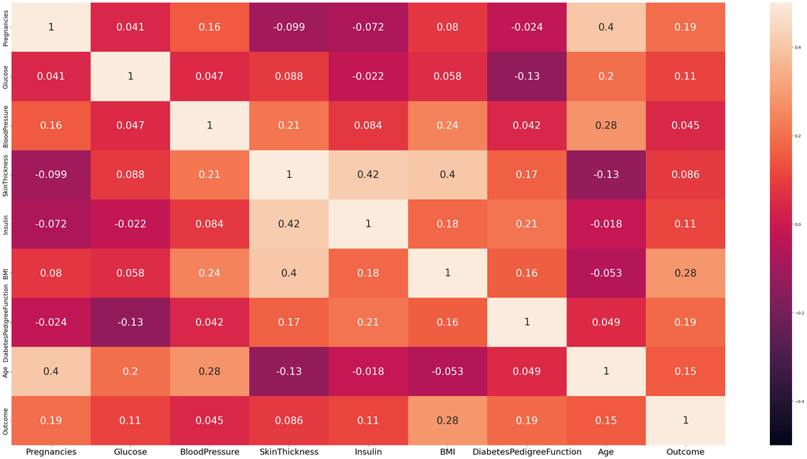

```python
plt.figure(figsize=(40, 20))
CorrelationHeatmap = sns.heatmap(DataFrame.corr(), vmin=-0.5, vmax=0.5, annot=True, annot_kws={"size":25})
CorrelationHeatmap.set_xticklabels(CorrelationHeatmap.get_xmajorticklabels(), fontsize =21)
CorrelationHeatmap.set_yticklabels(CorrelationHeatmap.get_ymajorticklabels(), fontsize =15)
```

```python
CorrelationHeatmap = DataFrame.corr()['Outcome'].sort_values()
display(CorrelationHeatmap)
```

```
BloodPressure               0.044803
SkinThickness               0.086170
Glucose                     0.105518
Insulin                     0.112239
Age                         0.152902
DiabetesPedigreeFunction    0.186958
Pregnancies                 0.193306
BMI                         0.284374
Outcome                     1.000000
Name: Outcome, dtype: float64
```

نمایش بالا از پایین به بالا بیشترین میزان وابستگی ها را نشان میدهد.

## Q4:

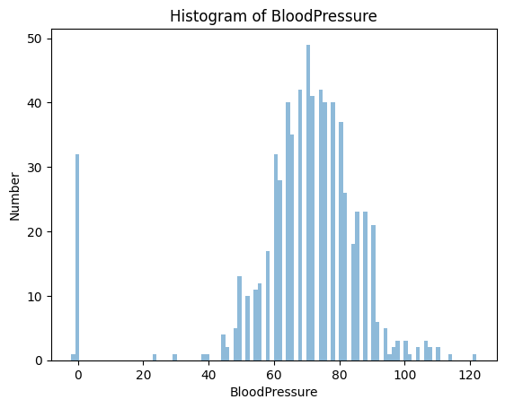

```python
plt.hist(DataFrame['BloodPressure'], range=(DataFrame['BloodPressure'].min(), DataFrame['BloodPressure'].max()), bins=100, alpha=0.5)
plt.xlabel("BloodPressure")
plt.ylabel("Number")
plt.title("Histogram of BloodPressure")
plt.show()
```

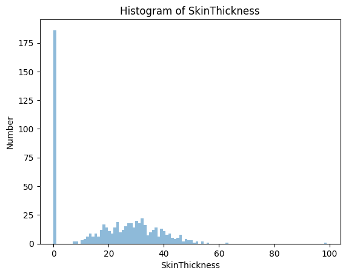

```python
plt.hist(DataFrame['SkinThickness'], range=(DataFrame['SkinThickness'].min(), DataFrame['SkinThickness'].max()), bins=100, alpha=0.5)
plt.xlabel("SkinThickness")
plt.ylabel("Number")
plt.title("Histogram of SkinThickness")
plt.show()
```

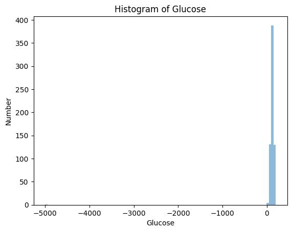

```python
plt.hist(DataFrame['Glucose'], range=(DataFrame['Glucose'].min(), DataFrame['Glucose'].max()), bins=100, alpha=0.5)
plt.xlabel("Glucose")
plt.ylabel("Number")
plt.title("Histogram of Glucose")
plt.show()
```

[figure not shown]

```python
plt.hist(DataFrame['Insulin'], range=(DataFrame['Insulin'].min(), DataFrame['Insulin'].max()), bins=100, alpha=0.5)
plt.xlabel("Insulin")
plt.ylabel("Number")
plt.title("Histogram of BloodPressure")
plt.show()
```

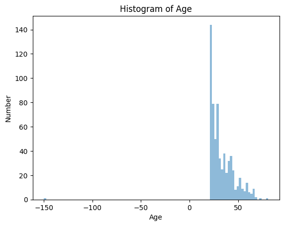

```python
plt.hist(DataFrame['Age'], range=(DataFrame['Age'].min(), DataFrame['Age'].max()), bins=100, alpha=0.5)
plt.xlabel("Age")
plt.ylabel("Number")
plt.title("Histogram of Age")
plt.show()
```

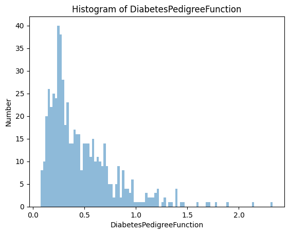

```python
plt.hist(DataFrame['DiabetesPedigreeFunction'], range=(DataFrame['DiabetesPedigreeFunction'].min(), DataFrame['DiabetesPedigreeFunction'].max()), bins=100, alpha=0.5)
plt.xlabel("DiabetesPedigreeFunction")
plt.ylabel("Number")
plt.title("Histogram of DiabetesPedigreeFunction")
plt.show()
```

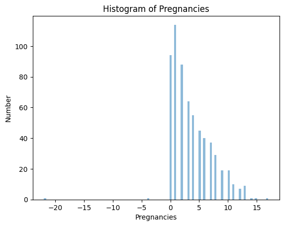

```python
plt.hist(DataFrame['Pregnancies'], range=(DataFrame['Pregnancies'].min(), DataFrame['Pregnancies'].max()), bins=100, alpha=0.5)
plt.xlabel("Pregnancies")
plt.ylabel("Number")
plt.title("Histogram of Pregnancies")
plt.show()
```

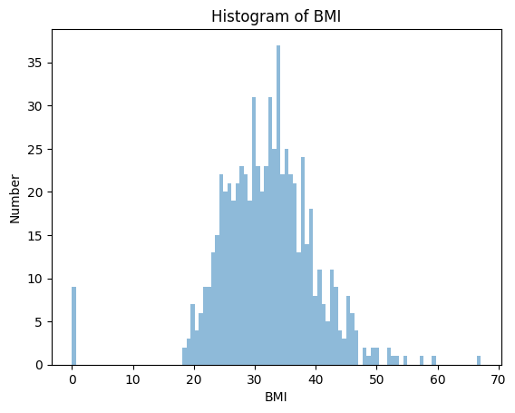

```python
plt.hist(DataFrame['BMI'], range=(DataFrame['BMI'].min(), DataFrame['BMI'].max()), bins=100, alpha=0.5)
plt.xlabel("BMI")
plt.ylabel("Number")
plt.title("Histogram of BMI")
plt.show()
```

## Q5:

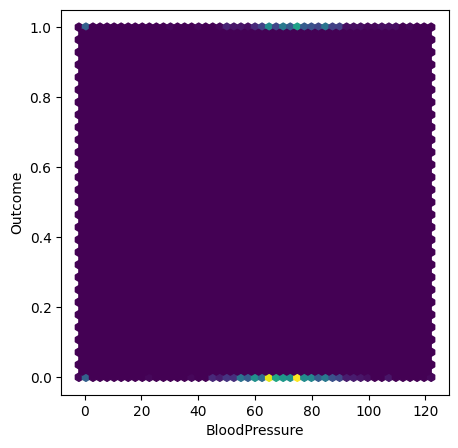

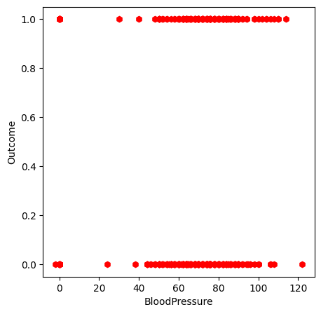

```python
plt.figure(figsize = (5, 5))
plt.hexbin(DataFrame["BloodPressure"], DataFrame["Outcome"], gridsize = 50,marginals=False)
plt.xlabel('BloodPressure')
plt.ylabel('Outcome')
plt.show()

plt.figure(figsize = (5, 5))
plt.scatter(DataFrame["BloodPressure"], DataFrame["Outcome"], c='red', marker="h")
plt.xlabel('BloodPressure')
plt.ylabel('Outcome')
plt.show()
```

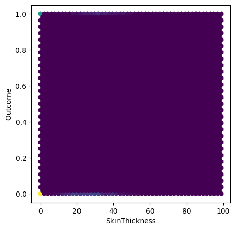

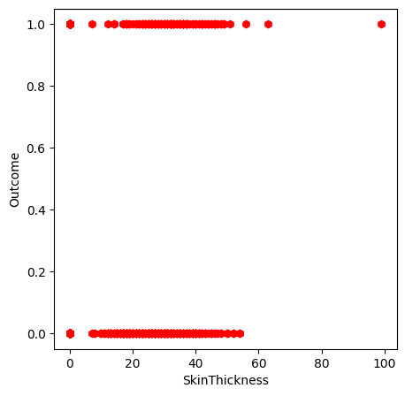

```python
plt.figure(figsize = (5, 5))
plt.hexbin(DataFrame["SkinThickness"], DataFrame["Outcome"], gridsize = 50,marginals=False)
plt.xlabel('SkinThickness')
plt.ylabel('Outcome')
plt.show()

plt.figure(figsize = (5, 5))
plt.scatter(DataFrame["SkinThickness"], DataFrame["Outcome"], c='red', marker="h")
plt.xlabel('SkinThickness')
plt.ylabel('Outcome')
plt.show()
```

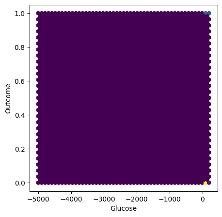

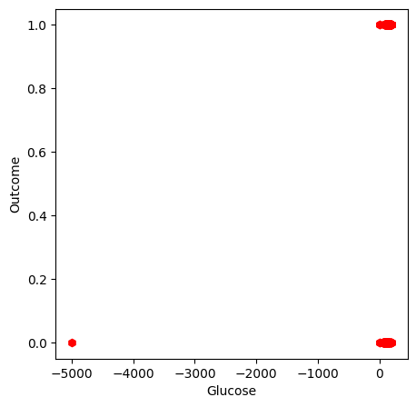

```python
plt.figure(figsize = (5, 5))
plt.hexbin(DataFrame["Glucose"], DataFrame["Outcome"], gridsize = 50,marginals=False)
plt.xlabel('Glucose')
plt.ylabel('Outcome')
plt.show()

plt.figure(figsize = (5, 5))
plt.scatter(DataFrame["Glucose"], DataFrame["Outcome"], c='red', marker="h")
plt.xlabel('Glucose')
plt.ylabel('Outcome')
plt.show()
```

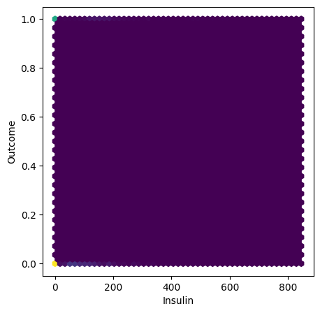

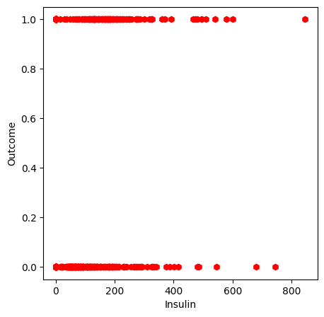

```python
plt.figure(figsize = (5, 5))
plt.hexbin(DataFrame["Insulin"], DataFrame["Outcome"], gridsize = 50)
plt.xlabel('Insulin')
plt.ylabel('Outcome')
plt.show()

plt.figure(figsize = (5, 5))
plt.scatter(DataFrame["Insulin"], DataFrame["Outcome"], c='red', marker="h")
plt.xlabel('Insulin')
plt.ylabel('Outcome')
plt.show()
```

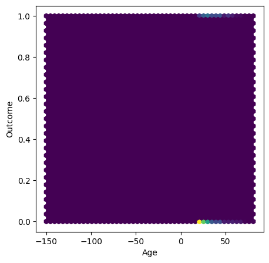

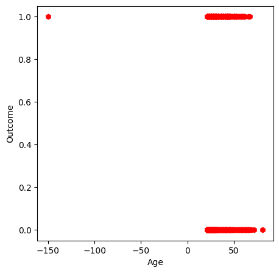

```python
plt.figure(figsize = (5, 5))
plt.hexbin(DataFrame["Age"], DataFrame["Outcome"], gridsize = 50,marginals=False)
plt.xlabel('Age')
plt.ylabel('Outcome')
plt.show()

plt.figure(figsize = (5, 5))
plt.scatter(DataFrame["Age"], DataFrame["Outcome"], c='red', marker="h")
plt.xlabel('Age')
plt.ylabel('Outcome')
plt.show()
```

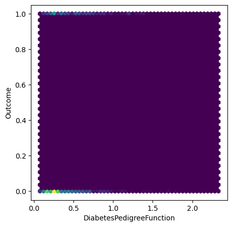

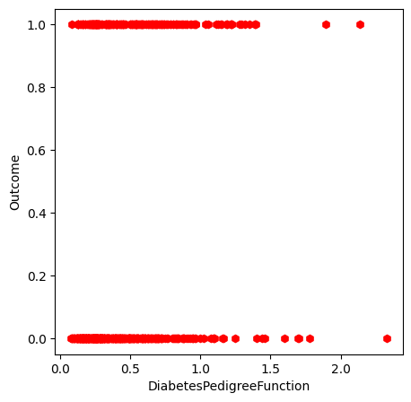

```python
plt.figure(figsize = (5, 5))
plt.hexbin(DataFrame["DiabetesPedigreeFunction"], DataFrame["Outcome"], gridsize = 50,marginals=False)
plt.xlabel('DiabetesPedigreeFunction')
plt.ylabel('Outcome')
plt.show()

plt.figure(figsize = (5, 5))
plt.scatter(DataFrame["DiabetesPedigreeFunction"], DataFrame["Outcome"], c='red', marker="h")
plt.xlabel('DiabetesPedigreeFunction')
plt.ylabel('Outcome')
plt.show()
```

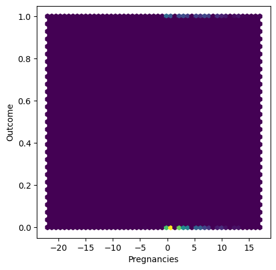

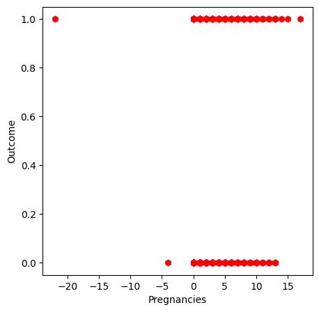

```python
plt.figure(figsize = (5, 5))
plt.hexbin(DataFrame["Pregnancies"], DataFrame["Outcome"], gridsize = 50,marginals=False)
plt.xlabel('Pregnancies')
plt.ylabel('Outcome')
plt.show()

plt.figure(figsize = (5, 5))
plt.scatter(DataFrame["Pregnancies"], DataFrame["Outcome"], c='red', marker="h")
plt.xlabel('Pregnancies')
plt.ylabel('Outcome')
plt.show()
```

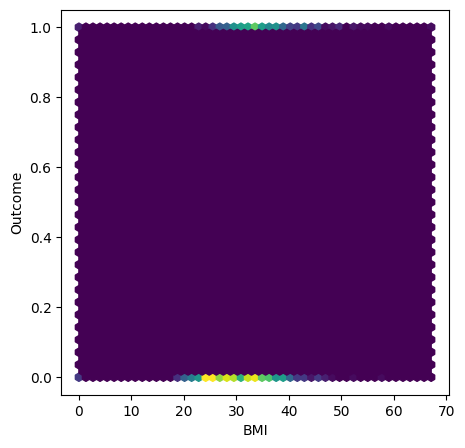

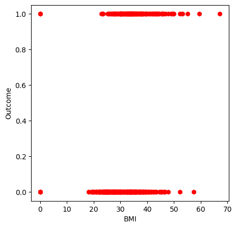

```python
plt.figure(figsize = (5, 5))
plt.hexbin(DataFrame["BMI"], DataFrame["Outcome"], gridsize = 50,marginals=False)
plt.xlabel('BMI')
plt.ylabel('Outcome')
plt.show()

plt.figure(figsize = (5, 5))
plt.scatter(DataFrame["BMI"], DataFrame["Outcome"], c='red', marker="h")
plt.xlabel('BMI')
plt.ylabel('Outcome')
plt.show()
```

# Phase One:

## Q1:

میدانیم که در مجموعه داده هایمان missing value های وجود دارد و ما با توجه به شرایط باید تصمیم بگیریم که از چه روشی استفاده کنیم تا آنهارا پوشیش دهیم. یکی از روش ها حذف کل ستون میباشد. در این روش باید دقت زیادی داشته باشیم که هر ستونی را به طور کامل پاک نکنیم. برای مثال ستون هایی که تاثیر زیادی بر رسیدن به جواب ما دارند را نباید حذف کنیم. این روش برای ستون هایی به کار میرود که تعداد missing values در آنها زیاد است و کمک چندانی به ما نمیتواند کند. از طرفی دیگر برخی از صفت ها تاثیر بسیار کمی بر روی جواب ما دارند که آنهارا میتوانیم حذف کنیم. برای مثال در پروژه ی صفر درس معیار شماره ی کابین تاثیر چندانی روی جواب ما نداشت و فراوانی مقادیر مختلف بسیار زیاد بود و در اصل به ما کمکی نمیکرد. این روش معمولا برای مجموعه های بزرگ بهتر از مجموعه های کوچک میباشد.

یکی از روش های دیگر پر کردن مقادیر خالی با استفاده از آماره ها میباشد. در این روش ما خانه هایی که NaN هستند را برای مثال با میانگین یا میانه یا مد پر میکنیم. مزیت این روش این است که چیز جدیدی به داده های ما اضافه نمیکند و مقداری منطقی به آن اضافه میشود اما از ضعف های آن میتوان به آن اشاره کرد که صرفا برای اعداد استفاده میشود و میتواند واریانس را افزایش دهد. بنظر میرسد این روش بهتر از روش قبل باشد.

برخی از روش های دیگر را به طور خلاصه توضیح میدهیم :

حذف کردن ردیف : در این روش به گونه عمل میکنیم که اگر NaN در یک ردیف وجود داشت میتوانیم آن را به طور کامل حذف کنیم و فرض کنی که همچین داده ای اصلا نداشته ایم.

جایگزین کردن خانه های NaN با پرتکرار ترین مقادیر : در این روش که برای غیر عددی ها هم بکار میرود مقداری را که بیشترین تکرار را داشته است جایگزین NaN ها در یک ستون میکنیم.

حدس زدن داده های از دست رفته : این روش ممکن است عملکرد بهتری از حذف داده ها داشته باشد.

## Q2:

```python
DataFrame.isna().sum()
```

```
Pregnancies                 133
Glucose                     114
BloodPressure                88
SkinThickness               144
Insulin                      88
BMI                          84
DiabetesPedigreeFunction    178
Age                         113
Outcome                       0
dtype: int64
```

```python
column_means = DataFrame.mean(numeric_only=True)
DataFrame[DataFrame < 0] = np.nan
DataFrame = DataFrame.fillna(column_means)
DataFrame.drop(columns=["SkinThickness"], inplace=True)
DataFrame.drop(columns=["Insulin"], inplace=True)
DataFrame.isna().sum()
```

```
Pregnancies                 0
Glucose                     0
BloodPressure               0
BMI                         0
DiabetesPedigreeFunction    0
Age                         0
Outcome                     0
dtype: int64
```

```python
DataFrame
```

|  | Pregnancies | Glucose | BloodPressure | BMI | DiabetesPedigreeFunction | Age | Outcome |
| --- | --- | --- | --- | --- | --- | --- | --- |
| 0 | 6.000000 | 148.000000 | 72.000000 | 33.600000 | 0.627000 | 50.000000 | 1 |
| 1 | 1.000000 | 85.000000 | 66.000000 | 26.600000 | 0.351000 | 31.000000 | 0 |
| 2 | 3.700787 | 183.000000 | 64.000000 | 23.300000 | 0.672000 | 32.000000 | 1 |
| 3 | 1.000000 | 89.000000 | 66.000000 | 28.100000 | 0.167000 | 21.000000 | 0 |
| 4 | 3.700787 | 137.000000 | 40.000000 | 32.083626 | 0.466676 | 33.000000 | 1 |
| ... | ... | ... | ... | ... | ... | ... | ... |
| 763 | 10.000000 | 101.000000 | 76.000000 | 32.900000 | 0.466676 | 63.000000 | 0 |
| 764 | 2.000000 | 122.000000 | 70.000000 | 36.800000 | 0.340000 | 33.157252 | 0 |
| 765 | 5.000000 | 113.422018 | 72.000000 | 26.200000 | 0.245000 | 30.000000 | 0 |
| 766 | 1.000000 | 126.000000 | 60.000000 | 30.100000 | 0.349000 | 33.157252 | 1 |
| 767 | 3.700787 | 93.000000 | 68.786765 | 30.400000 | 0.315000 | 23.000000 | 0 |

768 rows × 7 columns

## Q3:

ما با استفاده از روش های Normalization و Standardization میتوانیم داده های خودمان را مقیاس بندی کنیم. Normalization یا مقیاس بندی Min-Max به شکلی میباشد که مقادیر را بین صفر تا یک قرار میدهد. در سوی دیگر روش Standardization فرض میکند که داده های ما از توزیع گاوسی تبعیت میکند و به شکلی میباشد که مقادیر را در اطراف صفر قرار میدهد به شکلی که میانگین صفر و انحراف معیار ۱ میشود. همان طور که مشاهده میکنیم این دو روش برای مقیاس بندی به کار میرود که وقت هایی که ما میخواهیم داده هایمان در یک مقیاس باشند به کار ما می آیند.

```python
def standardizer(dt):
    scaler = StandardScaler()
    scaler = scaler.fit_transform(dt)
    scaler = pd.DataFrame(data=scaler, columns=['Pregnancies','Glucose','BloodPressure','BMI','DiabetesPedigreeFunction','Age','Outcome'])
    return scaler

def normalizer(dt):
    scaler = MinMaxScaler()
    scaler.fit(dt)
    scaled_features = scaler.transform(dt)
    DataFrame_MinMax = pd.DataFrame(data=scaled_features, columns=['Pregnancies','Glucose','BloodPressure','BMI','DiabetesPedigreeFunction','Age','Outcome'])
    return DataFrame_MinMax
```

```python
DataFrame
```

|  | Pregnancies | Glucose | BloodPressure | BMI | DiabetesPedigreeFunction | Age | Outcome |
| --- | --- | --- | --- | --- | --- | --- | --- |
| 0 | 6.000000 | 148.000000 | 72.000000 | 33.600000 | 0.627000 | 50.000000 | 1 |
| 1 | 1.000000 | 85.000000 | 66.000000 | 26.600000 | 0.351000 | 31.000000 | 0 |
| 2 | 3.700787 | 183.000000 | 64.000000 | 23.300000 | 0.672000 | 32.000000 | 1 |
| 3 | 1.000000 | 89.000000 | 66.000000 | 28.100000 | 0.167000 | 21.000000 | 0 |
| 4 | 3.700787 | 137.000000 | 40.000000 | 32.083626 | 0.466676 | 33.000000 | 1 |
| ... | ... | ... | ... | ... | ... | ... | ... |
| 763 | 10.000000 | 101.000000 | 76.000000 | 32.900000 | 0.466676 | 63.000000 | 0 |
| 764 | 2.000000 | 122.000000 | 70.000000 | 36.800000 | 0.340000 | 33.157252 | 0 |
| 765 | 5.000000 | 113.422018 | 72.000000 | 26.200000 | 0.245000 | 30.000000 | 0 |
| 766 | 1.000000 | 126.000000 | 60.000000 | 30.100000 | 0.349000 | 33.157252 | 1 |
| 767 | 3.700787 | 93.000000 | 68.786765 | 30.400000 | 0.315000 | 23.000000 | 0 |

768 rows × 7 columns

```python
DataFrame = normalizer(DataFrame)
DataFrame
```

|  | Pregnancies | Glucose | BloodPressure | BMI | DiabetesPedigreeFunction | Age | Outcome |
| --- | --- | --- | --- | --- | --- | --- | --- |
| 0 | 0.352941 | 0.743719 | 0.590164 | 0.500745 | 0.243892 | 0.483333 | 1.0 |
| 1 | 0.058824 | 0.427136 | 0.540984 | 0.396423 | 0.121279 | 0.166667 | 0.0 |
| 2 | 0.217693 | 0.919598 | 0.524590 | 0.347243 | 0.263883 | 0.183333 | 1.0 |
| 3 | 0.058824 | 0.447236 | 0.540984 | 0.418778 | 0.039538 | 0.000000 | 0.0 |
| 4 | 0.217693 | 0.688442 | 0.327869 | 0.478146 | 0.172668 | 0.200000 | 1.0 |
| ... | ... | ... | ... | ... | ... | ... | ... |
| 763 | 0.588235 | 0.507538 | 0.622951 | 0.490313 | 0.172668 | 0.700000 | 0.0 |
| 764 | 0.117647 | 0.613065 | 0.573770 | 0.548435 | 0.116393 | 0.202621 | 0.0 |
| 765 | 0.294118 | 0.569960 | 0.590164 | 0.390462 | 0.074189 | 0.150000 | 0.0 |
| 766 | 0.058824 | 0.633166 | 0.491803 | 0.448584 | 0.120391 | 0.202621 | 1.0 |
| 767 | 0.217693 | 0.467337 | 0.563826 | 0.453055 | 0.105287 | 0.033333 | 0.0 |

768 rows × 7 columns

## Q4:

ویژگی های دسته ای حالت های مختلفی دارند که آنهارا نام میبریم :

Binary : متغیری که فقط ۲ مقدار دارد. برای مثال True/Falseیا بله/خیر.

Ordinal : متغیری میباشد که ترتیبی در مقدار های آن وجود دارد مانند خوب/متوسط/بد.

Nominal : متغیری که اهمیت عددی ندارد و ترتیب خاصی ندارد مثلاً رنگ یا محل تولد.

حال روش های مختلفی وجود دارد که این داده هارا پیش پردازش کنیم که آنها به شرح زیر هستند :

Label Encoding : به این شکل میباشد که در هر ویژگی به هر مقدار آن یک عدد نسبت میدهیم.

One-hot encoding : این روش به این شکل میباشد که به تعداد مقدار های یک ویژگی، ویژگی اضافه میکنیم و به صورت one-hot عمل میکنیم به شکلی که در هر ردیف مقداری که ویژگی مدنظر ما دارد را یک میکنیم و بقیه را صفر میکنیم.

Target encoding : شامل جایگزینی هر گروه در یک ویژگی طبقه بندی شده با میانگین پاسخ در متغیر هدف است.

## Q6:

روش های مختلفی برای تقسیم داده ها بیین بخش Test و Train وجود دارد که آنهارا شرح میدهیم :

Leave-p-out : این روش به این شکل میباشد که p درصد از داده ها را به بخش Train اختصاص میدهیم و ما بقی را به بخش Test اختصاص میدهیم. و در ادامه با توجه به آموخته هایمان بر روی Train عملیات را بر روی Test انجام میدهیم.

Cross validation : این روش به این شکل میباشد که ابتدا بخشی از داده هارا به Train اختصاص میدهیم و ما بقی را به بخشی به نام Validation Data اختصاص میدهیم. سپس با انجام Train کردن داده ها روی آن عمل Testing را انجام میدهیم و سپس جای داده های Train را با Validaition Data جابجا میکنیم.

یکی از چیز هایی که مهم است این است که چه مقدار از داده هایمان را به بخش Train و چه بخشی از داده هایمان را به بخش Test اختصاص دهیم. برای اینکه بدانیم به چه نسبتی داده هایمان را تقسیم کنیم هدف مسئله و نوع مسئله ی مان بسیار مهم است. از طرفی حجم داده هایمان هم برای ما مهم است برای مثال اگر حجم داده هایمان کم باشد و درصد کمی از داده هایمان را به بخش Train اختصاص دهیم برنامه ی ما چیز زیاد یاد نمیگیرد و به خوبی کار نمیکند.

## Q7:

میتوانیم به جز بخش Train و Test بخش دیگری داشته باشیم به نام Validation یا Held-Out که این بخش هم مانند بخش Train برچسب هایش را میدانیم و بخش کوچک تری از Train میباشد و در این بخش قرار است هایپر پارامتر های ما تعیین شوند.

# Phase 2:

```python
def K_Nearest_Neighbours(numOfNeighbours, attributesTrain, answerTrain, attributesTest, answerTtest):
    KNN = KNeighborsRegressor(n_neighbors = numOfNeighbours)
    KNN.fit(attributesTrain, answerTrain)
    predictions = KNN.predict(attributesTest).round()
    cm = confusion_matrix(answerTtest, predictions)
    disp = ConfusionMatrixDisplay(confusion_matrix=cm)
    disp.plot()
    plt.title('K-Nearest-Neighbours', y=1)
    plt.ylabel('Actual label')
    plt.xlabel('Predicted label')
    plt.show()
    print("Accuracy:", metrics.accuracy_score(answerTtest, predictions))
    print("Precision:", metrics.precision_score(answerTtest, predictions))
    print("Recall:", metrics.recall_score(answerTtest, predictions))
```

```python
def Decision_Trees(depth, attributesTrain, answerTrain, attributesTest, answerTtest):
    DT = DecisionTreeRegressor(max_depth = depth)
    DT.fit(attributesTrain, answerTrain)
    predictions = DT.predict(attributesTest).round()
    cm = confusion_matrix(answerTtest, predictions)
    disp = ConfusionMatrixDisplay(confusion_matrix=cm)
    disp.plot()
    plt.title('Decision Trees', y=1)
    plt.ylabel('Actual label')
    plt.xlabel('Predicted label')
    plt.show()
    print("Accuracy:", metrics.accuracy_score(answerTtest, predictions))
    print("Precision:", metrics.precision_score(answerTtest, predictions))
    print("Recall:", metrics.recall_score(answerTtest, predictions))
```

```python
def Logistic_Regrssion(attributesTrain, answerTrain, attributesTest, answerTtest):
    LR = LogisticRegression(solver='liblinear')
    LR.fit(attributesTrain, answerTrain)
    predictions = LR.predict(attributesTest).round()
    cm = confusion_matrix(answerTtest, predictions)
    disp = ConfusionMatrixDisplay(confusion_matrix=cm)
    disp.plot()
    plt.title('Logistic Regrssion', y=1)
    plt.ylabel('Actual label')
    plt.xlabel('Predicted label')
    plt.show()
    print("Accuracy:", metrics.accuracy_score(answerTtest, predictions))
    print("Precision:", metrics.precision_score(answerTtest, predictions))
    print("Recall:", metrics.recall_score(answerTtest, predictions))
```

```python
def K_Nearest_Neighbours_Grid(numOfNeighbours, attributesTrain, answerTrain, attributesTest, answerTtest):
    KNN = KNeighborsRegressor(n_neighbors = numOfNeighbours)
    KNN = GridSearchCV(estimator=SVR(kernel='rbf'),
            param_grid={
                'C': [0.1, 1, 100, 1000],
                'epsilon': [0.0001, 0.0005, 0.001, 0.005, 0.01, 0.05, 0.1, 0.5, 1, 5, 10],
                'gamma': [0.0001, 0.001, 0.005, 0.1, 1, 3, 5]
            },
            cv=5, scoring='neg_mean_squared_error', verbose=0, n_jobs=-1)
    KNN.fit(attributesTrain, answerTrain)
    predictions = KNN.predict(attributesTest).round()
    cm = confusion_matrix(answerTtest, predictions)
    disp = ConfusionMatrixDisplay(confusion_matrix=cm)
    disp.plot()
    plt.title('K-Nearest-Neighbours Grid', y=1)
    plt.ylabel('Actual label')
    plt.xlabel('Predicted label')
    plt.show()
    print("Accuracy:", metrics.accuracy_score(answerTtest, predictions))
    print("Precision:", metrics.precision_score(answerTtest, predictions))
    print("Recall:", metrics.recall_score(answerTtest, predictions))
```

```python
def Decision_Trees_Grid(depth, attributesTrain, answerTrain, attributesTest, answerTtest):
    DT = DecisionTreeRegressor(max_depth = depth)
    DT = GridSearchCV(estimator=SVR(kernel='rbf'),
            param_grid={
                'C': [0.1, 1, 100, 1000],
                'epsilon': [0.0001, 0.0005, 0.001, 0.005, 0.01, 0.05, 0.1, 0.5, 1, 5, 10],
                'gamma': [0.0001, 0.001, 0.005, 0.1, 1, 3, 5]
            },
            cv=5, scoring='neg_mean_squared_error', verbose=0, n_jobs=-1)
    DT.fit(attributesTrain, answerTrain)
    predictions = DT.predict(attributesTest).round()
    cm = confusion_matrix(answerTtest, predictions)
    disp = ConfusionMatrixDisplay(confusion_matrix=cm)
    disp.plot()
    plt.title('Decision Trees Grid', y=1)
    plt.ylabel('Actual label')
    plt.xlabel('Predicted label')
    plt.show()
    print("Accuracy:", metrics.accuracy_score(answerTtest, predictions))
    print("Precision:", metrics.precision_score(answerTtest, predictions))
    print("Recall:", metrics.recall_score(answerTtest, predictions))
```

```python
def Logistic_Regrssion_Grid(attributesTrain, answerTrain, attributesTest, answerTtest):
    LR = LogisticRegression(solver='liblinear')
    LR = GridSearchCV(estimator=SVR(kernel='rbf'),
            param_grid={
                'C': [0.1, 1, 100, 1000],
                'epsilon': [0.0001, 0.0005, 0.001, 0.005, 0.01, 0.05, 0.1, 0.5, 1, 5, 10],
                'gamma': [0.0001, 0.001, 0.005, 0.1, 1, 3, 5]
            },
            cv=5, scoring='neg_mean_squared_error', verbose=0, n_jobs=-1)
    LR.fit(attributesTrain, answerTrain)
    predictions = LR.predict(attributesTest).round()
    cm = confusion_matrix(answerTtest, predictions)
    disp = ConfusionMatrixDisplay(confusion_matrix=cm)
    disp.plot()
    plt.title('Logistic Regrssion Grid', y=1)
    plt.ylabel('Actual label')
    plt.xlabel('Predicted label')
    plt.show()
    print("Accuracy:", metrics.accuracy_score(answerTtest, predictions))
    print("Precision:", metrics.precision_score(answerTtest, predictions))
    print("Recall:", metrics.recall_score(answerTtest, predictions))
```

```python
answer = DataFrame["Outcome"].values
attributes = DataFrame.drop(columns=["Outcome"])
attributesTrain, attributesTest, answerTrain, answerTtest = train_test_split(attributes, answer, test_size = 0.2, random_state=48)
```

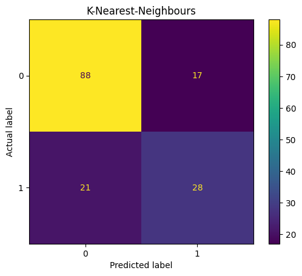

```
Accuracy: 0.7532467532467533
Precision: 0.6222222222222222
Recall: 0.5714285714285714
```

```python
K_Nearest_Neighbours(5, attributesTrain, answerTrain, attributesTest, answerTtest)
```

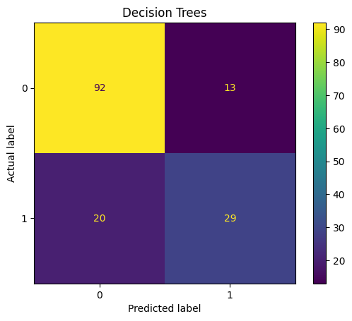

```
Accuracy: 0.7857142857142857
Precision: 0.6904761904761905
Recall: 0.5918367346938775
```

```python
Decision_Trees(5, attributesTrain, answerTrain, attributesTest, answerTtest)
```

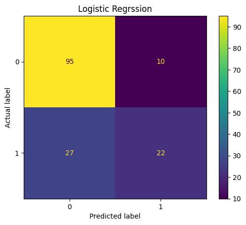

```
Accuracy: 0.7597402597402597
Precision: 0.6875
Recall: 0.4489795918367347
```

```python
Logistic_Regrssion(attributesTrain, answerTrain, attributesTest, answerTtest)
```

[figure not shown]

```
Accuracy: 0.7857142857142857
Precision: 0.7222222222222222
Recall: 0.5306122448979592
```

```python
K_Nearest_Neighbours_Grid(5, attributesTrain, answerTrain, attributesTest, answerTtest)
```

[figure not shown]

```
Accuracy: 0.7857142857142857
Precision: 0.7222222222222222
Recall: 0.5306122448979592
```

```python
Decision_Trees_Grid(5, attributesTrain, answerTrain, attributesTest, answerTtest)
```

[figure not shown]

```
Accuracy: 0.7857142857142857
Precision: 0.7222222222222222
Recall: 0.5306122448979592
```

```python
Logistic_Regrssion_Grid(attributesTrain, answerTrain, attributesTest, answerTtest)
```